# Regresión lineal

Mario Encinar

Julio de 2018

# Instrucciones para ajustar modelos lineales en R

La instrucción para ajustar un modelo lineal en R es `lm`:

`lm(formula, data, subset, weights, ...)`

donde

- `formula` es una descripción simbólica del modelo que se pretende ajustar.
- `data` es un *data frame* que contiene los datos con los que se pretende ajustar el modelo.
- `subset` es un vector opcional que especifica el subconjunto de observaciones que se van a usar en el proceso de ajuste.
- `weights` es un vector opcional de pesos que se van a usar en el proceso de ajuste del modelo. Por defecto `weights=NULL`, indicando que el ajuste se realizará por mínimos cuadrados ordinarios, y, en caso contrario, si se pasa un vector $w = (w_1, \dots, w_n)$, la función que se minimiza en el ajuste del modelo es el $MSE$ ponderado por $W$, es decir,
  $$MSE_w = \sum_{i=1}^{n} w_i e_i^2.$$

# El dataset `Advertising`

```r
library(dplyr)
advertising <- read.csv('advertising.csv', sep = ';', header = T, fileEncoding = 'utf-8')
glimpse(advertising)
```

```
## Observations: 200
## Variables: 4
## $ TV        <dbl> 230.1, 44.5, 17.2, 151.5, 180.8, 8.7, 57.5, 120.2, 8...
## $ Radio     <dbl> 37.8, 39.3, 45.9, 41.3, 10.8, 48.9, 32.8, 19.6, 2.1,...
## $ Newspaper <dbl> 69.2, 45.1, 69.3, 58.5, 58.4, 75.0, 23.5, 11.6, 1.0,...
## $ Sales     <dbl> 22.1, 10.4, 9.3, 18.5, 12.9, 7.2, 11.8, 13.2, 4.8, 1...
```

```r
summary(advertising)
```

```
##        TV             Radio          Newspaper          Sales
##  Min.   :  0.70   Min.   : 0.000   Min.   :  0.30   Min.   : 1.60
##  1st Qu.: 74.38   1st Qu.: 9.975   1st Qu.: 12.75   1st Qu.:10.38
##  Median :149.75   Median :22.900   Median : 25.75   Median :12.90
##  Mean   :147.04   Mean   :23.264   Mean   : 30.55   Mean   :14.02
##  3rd Qu.:218.82   3rd Qu.:36.525   3rd Qu.: 45.10   3rd Qu.:17.40
##  Max.   :296.40   Max.   :49.600   Max.   :114.00   Max.   :27.00
```

# Diagramas de dispersión por pares

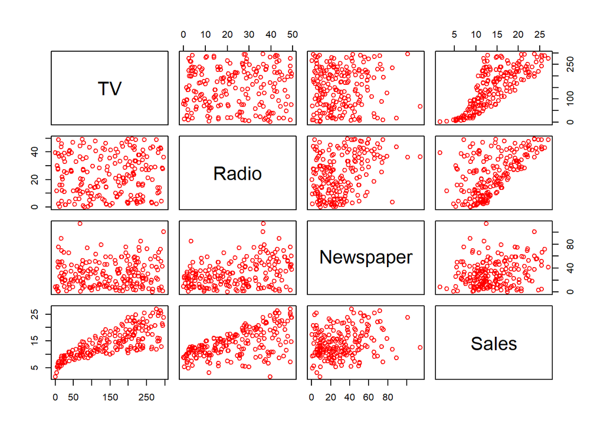

```r
pairs(advertising, col = 'red')
```

# Ajuste de un modelo lineal simple

`Sales` frente a `TV`:

```r
lm_fit_sales_TV <- lm(Sales ~ TV, data = advertising)

lm_fit_sales_TV
```

```
##
## Call:
## lm(formula = Sales ~ TV, data = advertising)
##
## Coefficients:
## (Intercept)           TV
##     7.03259      0.04754
```

El modelo es

$$Sales = 7.03259 + 0.04754\cdot TV$$

```r
summary(lm_fit_sales_TV)
```

```
##
## Call:
## lm(formula = Sales ~ TV, data = advertising)
##
## Residuals:
##     Min      1Q  Median      3Q     Max
## -8.3860 -1.9545 -0.1913  2.0671  7.2124
##
## Coefficients:
##             Estimate Std. Error t value Pr(>|t|)
## (Intercept) 7.032594   0.457843   15.36   <2e-16 ***
## TV          0.047537   0.002691   17.67   <2e-16 ***
## ---
## Signif. codes:  0 '***' 0.001 '**' 0.01 '*' 0.05 '.' 0.1 ' ' 1
##
## Residual standard error: 3.259 on 198 degrees of freedom
## Multiple R-squared:  0.6119, Adjusted R-squared:  0.6099
## F-statistic: 312.1 on 1 and 198 DF,  p-value: < 2.2e-16
```

```r
names(lm_fit_sales_TV)
```

```
##  [1] "coefficients"  "residuals"     "effects"       "rank"
##  [5] "fitted.values" "assign"        "qr"            "df.residual"
##  [9] "xlevels"       "call"          "terms"         "model"
```

Se pueden obtener intervalos de confianza para los coeficientes

```r
confint(lm_fit_sales_TV, level = 0.95)
```

```
##                  2.5 %     97.5 %
## (Intercept) 6.12971927 7.93546783
## TV          0.04223072 0.05284256
```

y se pueden hacer predicciones para datos nuevos

```r
new_advertising = data.frame(TV = c(100, 150, 200, 250))
predicted_values <- predict(lm_fit_sales_TV, new_advertising, interval = 'confidence')
new_advertising <- cbind(new_advertising, predicted_values)
new_advertising
```

```
##    TV      fit      lwr      upr
## 1 100 11.78626 11.26782 12.30470
## 2 150 14.16309 13.70842 14.61776
## 3 200 16.53992 16.00567 17.07418
## 4 250 18.91675 18.20619 19.62732
```

Podemos representar gráficamente el modelo sobre los datos de entrenamiento:

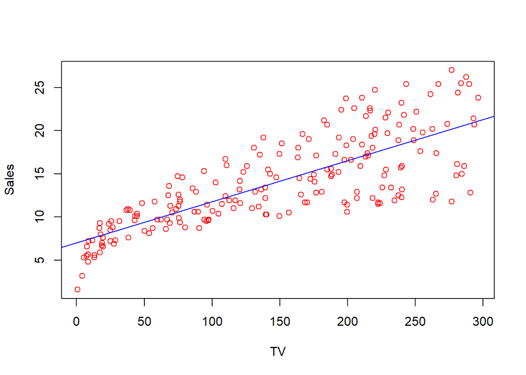

```r
plot(advertising$TV, advertising$Sales, type = 'p', col = 'red', xlab = 'TV', ylab = 'Sales')
abline(lm_fit_sales_TV, col = 'blue')
```

Por último, también podemos representar gráficamente los residuos del modelo:

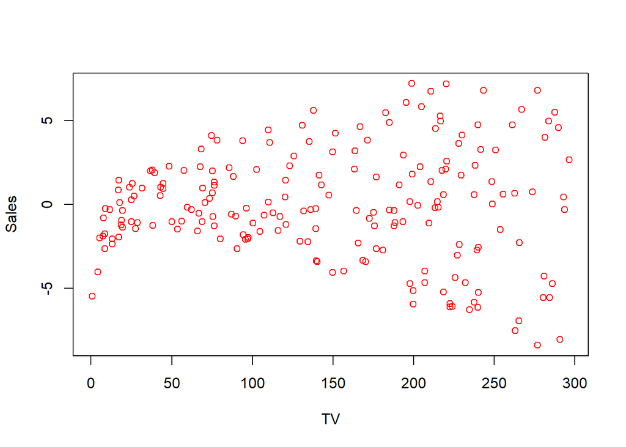

```r
plot(advertising$TV, lm_fit_sales_TV$residuals, type = 'p', col = 'red', xlab = 'TV', ylab = 'Sales')
```

**Ejercicio:** Considera el dataset `Auto`, que tienes disponible en el fichero `auto.csv` (puedes encontrar la descripción del dataset en la segunda página de [esto](https://cran.r-project.org/web/packages/ISLR/ISLR.pdf)).

- Ajusta un modelo lineal de `mpg` frente a `horsepower` y comenta los resultados. Por ejemplo:
- ¿Existe relación entre el predictor y la respuesta?
- ¿Cómo de fuerte es esa relación?
- ¿Es la relación entre el predictor y la respuesta positiva o negativa?
- ¿Cuál es el `mpg` predicho para un `horsepower` de 98? Da un intervalo de confianza del 99% para ese valor.
- Representa gráficamente la respuesta y el predictor, así como el modelo que has ajustado.
- Representa gráficamente los residuos del modelo y comenta posibles problemas que puedas encontrar.
- Intenta otro tipo de análisis en busca de algún insight *sorprendente*.

# Ajuste de un modelo lineal múltiple

Para ajustar un modelo de regresión lineal múltiple, la instrucción que se emplea es la misma que en el caso univariante, pero en la fórmula se han de especificar todas las variables que se pretenden considerar, separadas por un `+`. Así, para ajustar un modelo de `Sales` frente a `TV`, `Radio` y `Newspaper` hacemos

```r
lm_fit_sales_all <- lm(Sales ~ TV + Radio + Newspaper, data = advertising)
summary(lm_fit_sales_all)
```

```
##
## Call:
## lm(formula = Sales ~ TV + Radio + Newspaper, data = advertising)
##
## Residuals:
##     Min      1Q  Median      3Q     Max
## -8.8277 -0.8908  0.2418  1.1893  2.8292
##
## Coefficients:
##              Estimate Std. Error t value Pr(>|t|)
## (Intercept)  2.938889   0.311908   9.422   <2e-16 ***
## TV           0.045765   0.001395  32.809   <2e-16 ***
## Radio        0.188530   0.008611  21.893   <2e-16 ***
## Newspaper   -0.001037   0.005871  -0.177     0.86
## ---
## Signif. codes:  0 '***' 0.001 '**' 0.01 '*' 0.05 '.' 0.1 ' ' 1
##
## Residual standard error: 1.686 on 196 degrees of freedom
## Multiple R-squared:  0.8972, Adjusted R-squared:  0.8956
## F-statistic: 570.3 on 3 and 196 DF,  p-value: < 2.2e-16
```

El modelo que se obtiene es

$$Sales = 2.938889 + 0.045765\cdot TV + 0.188530 \cdot Radio - 0.001037 \cdot Newspaper$$

Una llamada equivalente a la que hemos hecho sería

```r
lm_fit_sales_all <- lm(Sales ~ ., data = advertising)
```

ya que el punto quiere decir “todas las demás variables”. Si quieren quitarse variables, se utiliza un `-`. Así, una forma de ajustar un modelo de `Sales` frente a `TV` y `Radio` sería

```r
lm_fit_sales_TV_Radio <- lm(Sales ~ . - Newspaper, data = advertising)
```

```r
summary(lm_fit_sales_TV_Radio)
```

```
##
## Call:
## lm(formula = Sales ~ . - Newspaper, data = advertising)
##
## Residuals:
##     Min      1Q  Median      3Q     Max
## -8.7977 -0.8752  0.2422  1.1708  2.8328
##
## Coefficients:
##             Estimate Std. Error t value Pr(>|t|)
## (Intercept)  2.92110    0.29449   9.919   <2e-16 ***
## TV           0.04575    0.00139  32.909   <2e-16 ***
## Radio        0.18799    0.00804  23.382   <2e-16 ***
## ---
## Signif. codes:  0 '***' 0.001 '**' 0.01 '*' 0.05 '.' 0.1 ' ' 1
##
## Residual standard error: 1.681 on 197 degrees of freedom
## Multiple R-squared:  0.8972, Adjusted R-squared:  0.8962
## F-statistic: 859.6 on 2 and 197 DF,  p-value: < 2.2e-16
```

Cuando hay más de un predictor, el análisis gráfico del modelo es diferente (ya que las representaciones en más de dos dimensiones suelen ser difíciles de leer). En este caso, representamos valores reales frente a predichos y residuos frente a valores reales:

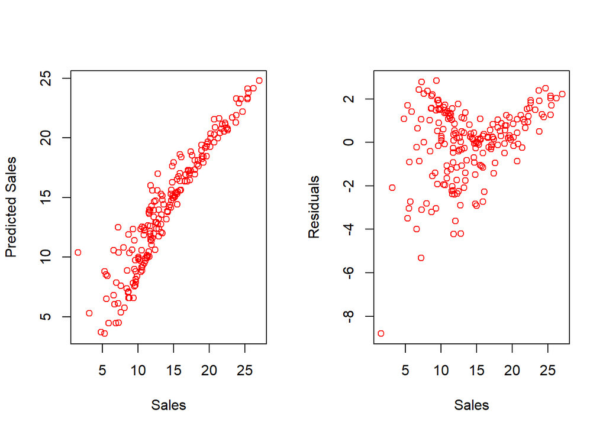

```r
par(mfrow = c(1,2))

plot(advertising$Sales, lm_fit_sales_TV_Radio$fitted.values, type = 'p', col = 'red', xlab = 'Sales', ylab = 'Predicted Sales')
plot(advertising$Sales, lm_fit_sales_TV_Radio$residuals, type = 'p', col = 'red', xlab = 'Sales', ylab = 'Residuals')
```

**Ejercicio:** Sobre el dataset `Auto` de antes:

- Realiza un análisis exploratorio sencillo.
- Representa diagramas de dispersión de todos los pares de variables numéricas. Calcula la matriz de correlaciones. A priori, ¿piensas que tiene sentido ajustar un modelo lineal de `mpg` frente al resto de variables, o frente a algunas de ellas?
- Para confirmar o desmentir tu sospecha, ajusta tal modelo y trata de *optimizarlo*. Responde a las siguientes preguntas:
- ¿Existe relación entre los predictores y la respuesta?
- ¿Cómo varía la respuesta frente a cada uno de los predictores?
- ¿Parecen existir problemas en el ajuste del modelo?